# STAT340 HW04: Models

## Question 5

```r
# make sure you have the ISLR package
library(ISLR)

# you should read the help page by running ?Carseats
# we can also peek at the data frame before using it
str(Carseats)
```

```
## 'data.frame':    400 obs. of  11 variables:
##  $ Sales      : num  9.5 11.22 10.06 7.4 4.15 ...
##  $ CompPrice  : num  138 111 113 117 141 124 115 136 132 132 ...
##  $ Income     : num  73 48 35 100 64 113 105 81 110 113 ...
##  $ Advertising: num  11 16 10 4 3 13 0 15 0 0 ...
##  $ Population : num  276 260 269 466 340 501 45 425 108 131 ...
##  $ Price      : num  120 83 80 97 128 72 108 120 124 124 ...
##  $ ShelveLoc  : Factor w/ 3 levels "Bad","Good","Medium": 1 2 3 3 1 1 3 2 3 3 ...
##  $ Age        : num  42 65 59 55 38 78 71 67 76 76 ...
##  $ Education  : num  17 10 12 14 13 16 15 10 10 17 ...
##  $ Urban      : Factor w/ 2 levels "No","Yes": 2 2 2 2 2 1 2 2 1 1 ...
##  $ US         : Factor w/ 2 levels "No","Yes": 2 2 2 2 1 2 1 2 1 2 ...
```

```r
head(Carseats)
```

```
##   Sales CompPrice Income Advertising Population Price ShelveLoc Age
## 1  9.50       138     73          11        276   120       Bad  42
## 2 11.22       111     48          16        260    83      Good  65
## 3 10.06       113     35          10        269    80    Medium  59
## 4  7.40       117    100           4        466    97    Medium  55
## 5  4.15       141     64           3        340   128       Bad  38
## 6 10.81       124    113          13        501    72       Bad  78
##   Education Urban  US
## 1        17   Yes Yes
## 2        10   Yes Yes
## 3        12   Yes Yes
## 4        14   Yes Yes
## 5        13   Yes  No
## 6        16    No Yes
```

This question should be answered using the `Carseats` dataset from the `ISLR` package.

1. First, make some visualizations of the dataset to help set the stage for the rest of the analysis. Try to pick plots to show that are interesting informative.

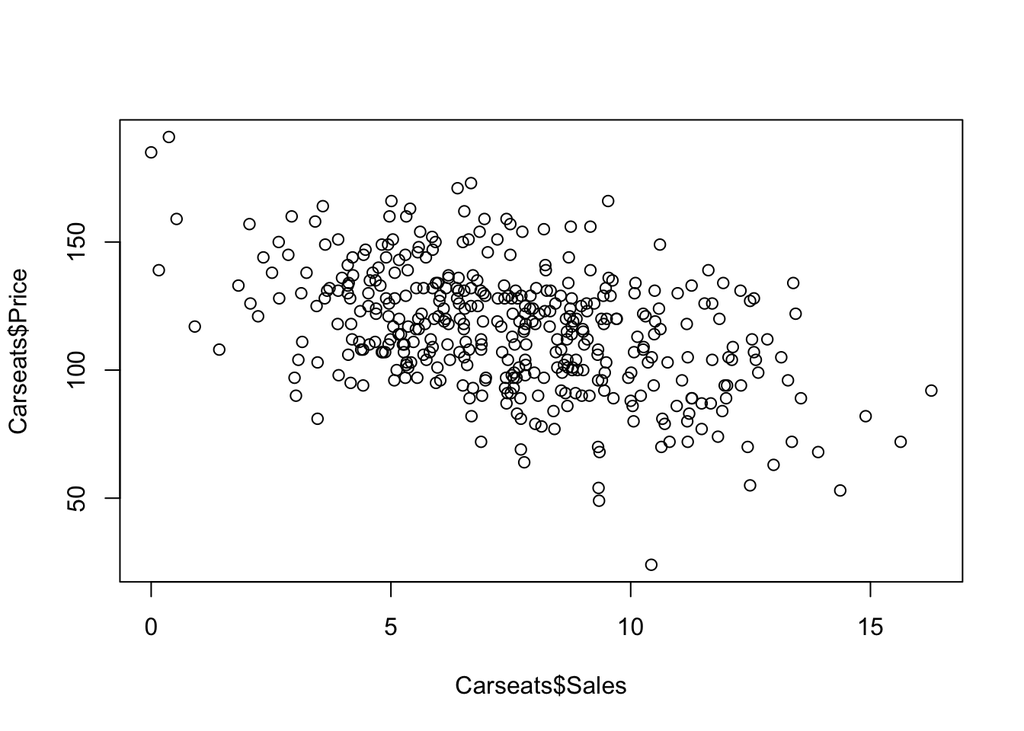

```r
Carseats = Carseats
plot(Carseats$Sales, Carseats$Price)
```

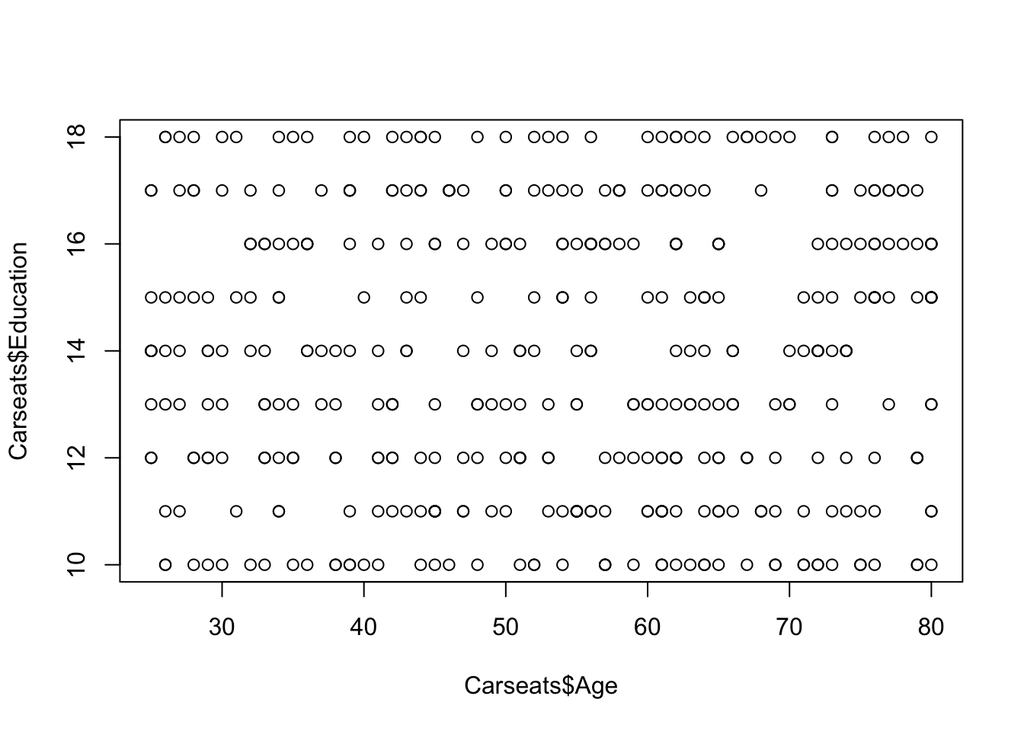

```r
plot(Carseats$Age, Carseats$Education)
```

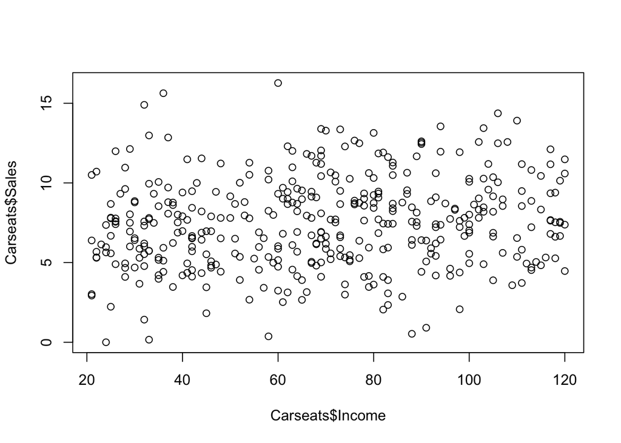

```r
plot(Carseats$Income, Carseats$Sales)
```

2. Using some variable selection method (CV, stepwise, LASSO, ridge, or even something else), choose a set of predictors to use to predict `Sales`. Try to find the best model that you can that explains the data well and doesn’t have useless predictors.

```r
library(MASS)
lambda_vals <- c(0,1,2,5,10,20,50,100,200,500) # Choose lambdas to try.
lambda_vals <- seq(1,50, length.out = 4001)
ridge_models <- lm.ridge(Sales~., Carseats, lambda=lambda_vals)

sanity_check <- lm(Sales~., Carseats)
mean((predict(sanity_check, Carseats) - Carseats$Sales )^2 )
```

```
## [1] 1.007084
```

```r
library(glmnet)
x = model.matrix(Sales~.,Carseats)[,-1]
y = Carseats$Sales

# fit lasso using default lambda values, alpha=1 adds LASSO penalty to RSS
lm.lasso = glmnet(x,y,alpha=1, lambda.min.ratio = .1)

# use CV to choose which lambda gives lowest MSE
cv.out = cv.glmnet(x,y,alpha=1)
lambda.best =  cv.out$lambda.min
lambda.best
```

```
## [1] 0.004020658
```

```r
coef(lm.lasso, s=lambda.best)
```

```
## 12 x 1 sparse Matrix of class "dgCMatrix"
##                          s1
## (Intercept)      7.07906369
## CompPrice        0.06993198
## Income           0.01001682
## Advertising      0.09446929
## Population       .
## Price           -0.07966306
## ShelveLocGood    4.00759637
## ShelveLocMedium  1.25163373
## Age             -0.03655719
## Education        .
## UrbanYes         .
## USYes            .
```

```r
predictor = predict(lm.lasso, s=lambda.best, newx=x)
#cv.out$lambda
```

3. Which predictors appear to be the most important or significant in predicting sales? Provide an interpretation of each coefficient in your model. Be careful—some of the variables in the model are qualitative!

```r
#The most imprtant predictors appeat to be CompPrice, ShelvelocGood and ShelvelocMedium, Advertising, and Price. Age and Income also appear significant but not the most. 0.069 is a one unit price change from each competitor will change the sales positively by 0.069 thousand. Income will increase sales by .01 thousand. Similarly, advertising increases sales by .09 thousand because an owner can afford it more. Price decreases sales by .079 thousand because a more expensive carseat decreases sales. Shelveloc Good incresaes sales by 4.01 thousand because safety is important. Shelveloc Medium increases sales by 1.25 thousand similarly to Shelveloc Good. And finally, age decreases sales by .036 because the higher age, the less likely a person is going to buy a carseat.
```

4. Provide $90\%$ confidence intervals for each coefficient in your model.

```r
linear = lm(Sales ~ CompPrice+Income+Advertising+Price+Age+ShelveLoc, Carseats)
confint(linear, "CompPrice", .9)
```

```
##                  5 %       95 %
## CompPrice 0.08577323 0.09936971
```

```r
confint(linear, "Income", .9)
```

```
##               5 %       95 %
## Income 0.01275515 0.01881479
```

```r
confint(linear, "Advertising", .9)
```

```
##                   5 %      95 %
## Advertising 0.1031691 0.1286377
```

```r
confint(linear, "Price", .9)
```

```
##               5 %        95 %
## Price -0.09972127 -0.09091664
```

```r
confint(linear, "Age", .9)
```

```
##             5 %        95 %
## Age -0.05136509 -0.04088995
```

```r
confint(linear, 'ShelveLocGood', .9)
```

```
##                    5 %     95 %
## ShelveLocGood 4.584242 5.087107
```

```r
confint(linear, 'ShelveLocMedium', .9)
```

```
##                      5 %     95 %
## ShelveLocMedium 1.745281 2.158705
```

```r
mean(linear$residuals^2)
```

```
## [1] 1.018467
```

6. Check the residuals. Do you think this is an appropriate model to use? Why or why not?

```r
res <- resid(linear)
linear$residuals
```

[output not shown]

[output cut: 105 more lines]

[output not shown]

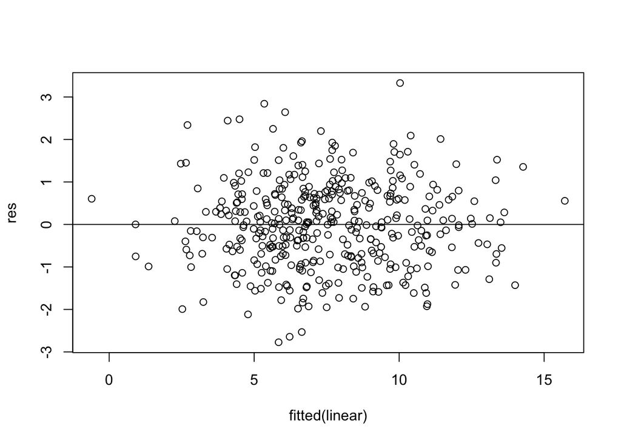

```r
plot(fitted(linear), res)
abline(0,0)
```

```r
#This is an appropriate model to use because the residuals do not appear to have correlation with the fitted values which means that it is strongly correlated with the true values of the data.
```